# Risk Factor Analysis

## Outcome Variable

**Outcome Variable:** stunted

## Predictor Variables

**Intervention Variable:** pers_wast

**Adjustment Set:**

- arm
- sex
- brthmon
- W_mage
- meducyrs
- hhwealth_quart
- W_nrooms
- month
- W_parity
- delta_W_mage
- delta_meducyrs
- delta_hhwealth_quart
- delta_W_nrooms
- delta_month
- delta_W_parity

## Stratifying Variables

The analysis was stratified on these variable(s):

- agecat
- studyid
- country

## Data Summary

| agecat | studyid | country | pers_wast | stunted | n_cell | n |
| --- | --- | --- | --- | --- | --- | --- |
| Birth | CMC-V-BCS-2002 | INDIA | 0 | 0 | 68 | 92 |
| Birth | CMC-V-BCS-2002 | INDIA | 0 | 1 | 12 | 92 |
| Birth | CMC-V-BCS-2002 | INDIA | 1 | 0 | 7 | 92 |
| Birth | CMC-V-BCS-2002 | INDIA | 1 | 1 | 5 | 92 |
| Birth | CMIN | BANGLADESH | 0 | 0 | 14 | 18 |
| Birth | CMIN | BANGLADESH | 0 | 1 | 2 | 18 |
| Birth | CMIN | BANGLADESH | 1 | 0 | 1 | 18 |
| Birth | CMIN | BANGLADESH | 1 | 1 | 1 | 18 |
| Birth | CONTENT | PERU | 0 | 0 | 2 | 2 |
| Birth | CONTENT | PERU | 0 | 1 | 0 | 2 |
| Birth | CONTENT | PERU | 1 | 0 | 0 | 2 |
| Birth | CONTENT | PERU | 1 | 1 | 0 | 2 |
| Birth | EE | PAKISTAN | 0 | 0 | 130 | 240 |
| Birth | EE | PAKISTAN | 0 | 1 | 94 | 240 |
| Birth | EE | PAKISTAN | 1 | 0 | 10 | 240 |
| Birth | EE | PAKISTAN | 1 | 1 | 6 | 240 |
| Birth | GMS-Nepal | NEPAL | 0 | 0 | 435 | 585 |
| Birth | GMS-Nepal | NEPAL | 0 | 1 | 86 | 585 |
| Birth | GMS-Nepal | NEPAL | 1 | 0 | 55 | 585 |
| Birth | GMS-Nepal | NEPAL | 1 | 1 | 9 | 585 |
| Birth | IRC | INDIA | 0 | 0 | 279 | 387 |
| Birth | IRC | INDIA | 0 | 1 | 40 | 387 |
| Birth | IRC | INDIA | 1 | 0 | 63 | 387 |
| Birth | IRC | INDIA | 1 | 1 | 5 | 387 |
| Birth | Keneba | GAMBIA | 0 | 0 | 1303 | 1419 |
| Birth | Keneba | GAMBIA | 0 | 1 | 71 | 1419 |
| Birth | Keneba | GAMBIA | 1 | 0 | 43 | 1419 |
| Birth | Keneba | GAMBIA | 1 | 1 | 2 | 1419 |
| Birth | MAL-ED | BANGLADESH | 0 | 0 | 180 | 229 |
| Birth | MAL-ED | BANGLADESH | 0 | 1 | 40 | 229 |

[output cut: 170 more lines]

The following strata were considered:

- agecat: 24 months, studyid: CMC-V-BCS-2002, country: INDIA
- agecat: 24 months, studyid: CMIN, country: BANGLADESH
- agecat: 24 months, studyid: CONTENT, country: PERU
- agecat: 24 months, studyid: EE, country: PAKISTAN
- agecat: 24 months, studyid: GMS-Nepal, country: NEPAL
- agecat: 24 months, studyid: IRC, country: INDIA
- agecat: 24 months, studyid: Keneba, country: GAMBIA
- agecat: 24 months, studyid: MAL-ED, country: BANGLADESH
- agecat: 24 months, studyid: MAL-ED, country: BRAZIL
- agecat: 24 months, studyid: MAL-ED, country: INDIA
- agecat: 24 months, studyid: MAL-ED, country: NEPAL
- agecat: 24 months, studyid: MAL-ED, country: PERU
- agecat: 24 months, studyid: MAL-ED, country: SOUTH AFRICA
- agecat: 24 months, studyid: MAL-ED, country: TANZANIA, UNITED REPUBLIC OF
- agecat: 24 months, studyid: PROVIDE, country: BANGLADESH
- agecat: 24 months, studyid: TanzaniaChild2, country: TANZANIA, UNITED REPUBLIC OF
- agecat: 6 months, studyid: CMC-V-BCS-2002, country: INDIA
- agecat: 6 months, studyid: CMIN, country: BANGLADESH
- agecat: 6 months, studyid: CONTENT, country: PERU
- agecat: 6 months, studyid: EE, country: PAKISTAN
- agecat: 6 months, studyid: GMS-Nepal, country: NEPAL
- agecat: 6 months, studyid: Guatemala BSC, country: GUATEMALA
- agecat: 6 months, studyid: IRC, country: INDIA
- agecat: 6 months, studyid: Keneba, country: GAMBIA
- agecat: 6 months, studyid: MAL-ED, country: BANGLADESH
- agecat: 6 months, studyid: MAL-ED, country: BRAZIL
- agecat: 6 months, studyid: MAL-ED, country: INDIA
- agecat: 6 months, studyid: MAL-ED, country: NEPAL
- agecat: 6 months, studyid: MAL-ED, country: PERU
- agecat: 6 months, studyid: MAL-ED, country: SOUTH AFRICA
- agecat: 6 months, studyid: MAL-ED, country: TANZANIA, UNITED REPUBLIC OF
- agecat: 6 months, studyid: PROVIDE, country: BANGLADESH
- agecat: 6 months, studyid: ResPak, country: PAKISTAN
- agecat: 6 months, studyid: TanzaniaChild2, country: TANZANIA, UNITED REPUBLIC OF
- agecat: Birth, studyid: CMC-V-BCS-2002, country: INDIA
- agecat: Birth, studyid: CMIN, country: BANGLADESH
- agecat: Birth, studyid: CONTENT, country: PERU
- agecat: Birth, studyid: EE, country: PAKISTAN
- agecat: Birth, studyid: GMS-Nepal, country: NEPAL
- agecat: Birth, studyid: IRC, country: INDIA
- agecat: Birth, studyid: Keneba, country: GAMBIA
- agecat: Birth, studyid: MAL-ED, country: BANGLADESH
- agecat: Birth, studyid: MAL-ED, country: BRAZIL
- agecat: Birth, studyid: MAL-ED, country: INDIA
- agecat: Birth, studyid: MAL-ED, country: NEPAL
- agecat: Birth, studyid: MAL-ED, country: PERU
- agecat: Birth, studyid: MAL-ED, country: SOUTH AFRICA
- agecat: Birth, studyid: MAL-ED, country: TANZANIA, UNITED REPUBLIC OF
- agecat: Birth, studyid: PROVIDE, country: BANGLADESH
- agecat: Birth, studyid: ResPak, country: PAKISTAN

### Dropped Strata

Some strata were dropped due to rare outcomes:

- agecat: Birth, studyid: CMIN, country: BANGLADESH
- agecat: Birth, studyid: CONTENT, country: PERU
- agecat: Birth, studyid: Keneba, country: GAMBIA
- agecat: Birth, studyid: MAL-ED, country: BANGLADESH
- agecat: Birth, studyid: MAL-ED, country: BRAZIL
- agecat: Birth, studyid: MAL-ED, country: INDIA
- agecat: Birth, studyid: MAL-ED, country: NEPAL
- agecat: Birth, studyid: MAL-ED, country: PERU
- agecat: Birth, studyid: MAL-ED, country: SOUTH AFRICA
- agecat: Birth, studyid: MAL-ED, country: TANZANIA, UNITED REPUBLIC OF
- agecat: Birth, studyid: PROVIDE, country: BANGLADESH
- agecat: Birth, studyid: ResPak, country: PAKISTAN
- agecat: 6 months, studyid: CMIN, country: BANGLADESH
- agecat: 6 months, studyid: CONTENT, country: PERU
- agecat: 6 months, studyid: Guatemala BSC, country: GUATEMALA
- agecat: 6 months, studyid: MAL-ED, country: BANGLADESH
- agecat: 6 months, studyid: MAL-ED, country: BRAZIL
- agecat: 6 months, studyid: MAL-ED, country: INDIA
- agecat: 6 months, studyid: MAL-ED, country: NEPAL
- agecat: 6 months, studyid: MAL-ED, country: PERU
- agecat: 6 months, studyid: MAL-ED, country: SOUTH AFRICA
- agecat: 6 months, studyid: MAL-ED, country: TANZANIA, UNITED REPUBLIC OF
- agecat: 6 months, studyid: ResPak, country: PAKISTAN
- agecat: 6 months, studyid: TanzaniaChild2, country: TANZANIA, UNITED REPUBLIC OF
- agecat: 24 months, studyid: CMIN, country: BANGLADESH
- agecat: 24 months, studyid: CONTENT, country: PERU
- agecat: 24 months, studyid: EE, country: PAKISTAN
- agecat: 24 months, studyid: MAL-ED, country: BANGLADESH
- agecat: 24 months, studyid: MAL-ED, country: BRAZIL
- agecat: 24 months, studyid: MAL-ED, country: INDIA
- agecat: 24 months, studyid: MAL-ED, country: NEPAL
- agecat: 24 months, studyid: MAL-ED, country: PERU
- agecat: 24 months, studyid: MAL-ED, country: SOUTH AFRICA
- agecat: 24 months, studyid: MAL-ED, country: TANZANIA, UNITED REPUBLIC OF
- agecat: 24 months, studyid: PROVIDE, country: BANGLADESH
- agecat: 24 months, studyid: TanzaniaChild2, country: TANZANIA, UNITED REPUBLIC OF

## Methods Detail

We’re interested in the causal parameters $E[Y_a]$ for all values of $a \in \mathcal{A}$. These parameters represent the mean outcome if, possibly contrary to fact, we intervened to set all units to have $A=a$. Under the randomization and positivity assumptions, these are identified by the statistical parameters $\psi_a=E_W[E_{Y|A,W}(Y|A=a,W)]$. In addition, we’re interested in the mean of $Y$, $E[Y]$ under no intervention (the observed mean). We will estimate these parameters by using SuperLearner to fit the relevant likelihood factors – $E_{Y|A,W}(Y|A=a,W)$ and $p(A=a|W)$, and then updating our likelihood fit using a joint TMLE.

For unadjusted analyses ($W=\{\}$), initial likelihoods were estimated using Lrnr_glm to estimate the simple $E(Y|A)$ and Lrnr_mean to estimate $p(A)$. For adjusted analyses, a small library containing Lrnr_glmnet, Lrnr_xgboost, and Lrnr_mean was used.

Having estimated these parameters, we will then use the delta method to estimate relative risks and attributable risks relative to a prespecified baseline level of $A$.

# Results Detail

## Results Plots

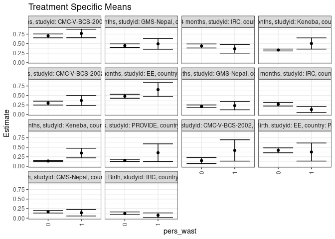

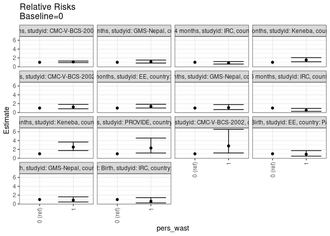

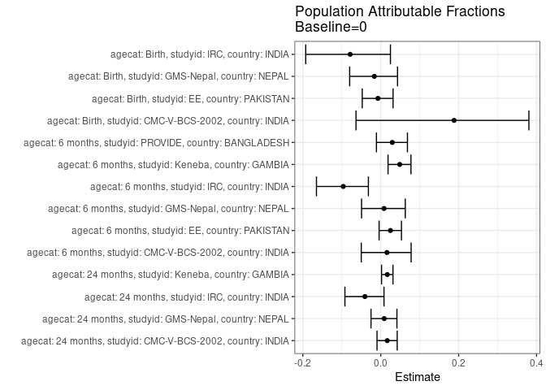

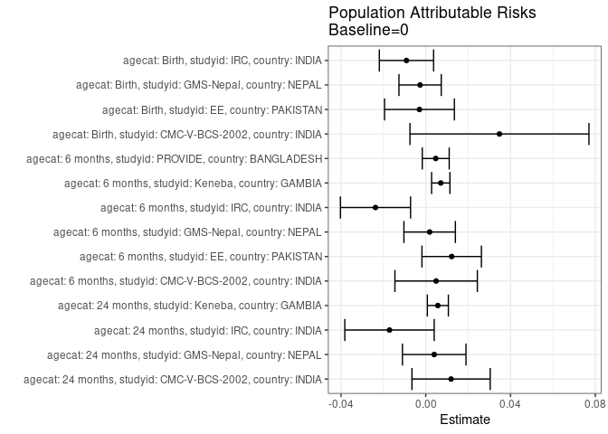

## Results Table

### Parameter: TSM

| agecat | studyid | country | intervention_level | baseline_level | estimate | ci_lower | ci_upper |
| --- | --- | --- | --- | --- | --- | --- | --- |
| Birth | CMC-V-BCS-2002 | INDIA | 0 | NA | 0.1500000 | 0.0713260 | 0.2286740 |
| Birth | CMC-V-BCS-2002 | INDIA | 1 | NA | 0.4166667 | 0.1361986 | 0.6971348 |
| Birth | EE | PAKISTAN | 0 | NA | 0.4196429 | 0.3548811 | 0.4844046 |
| Birth | EE | PAKISTAN | 1 | NA | 0.3750000 | 0.1372884 | 0.6127116 |
| Birth | GMS-Nepal | NEPAL | 0 | NA | 0.1650672 | 0.1331623 | 0.1969720 |
| Birth | GMS-Nepal | NEPAL | 1 | NA | 0.1406250 | 0.0553833 | 0.2258667 |
| Birth | IRC | INDIA | 0 | NA | 0.1253918 | 0.0890040 | 0.1617797 |
| Birth | IRC | INDIA | 1 | NA | 0.0735294 | 0.0114136 | 0.1356452 |
| 6 months | CMC-V-BCS-2002 | INDIA | 0 | NA | 0.2992146 | 0.2483394 | 0.3500898 |
| 6 months | CMC-V-BCS-2002 | INDIA | 1 | NA | 0.3676485 | 0.2362916 | 0.4990054 |
| 6 months | EE | PAKISTAN | 0 | NA | 0.4783862 | 0.4257566 | 0.5310158 |
| 6 months | EE | PAKISTAN | 1 | NA | 0.6538462 | 0.4707342 | 0.8369581 |
| 6 months | GMS-Nepal | NEPAL | 0 | NA | 0.2146275 | 0.1785533 | 0.2507018 |
| 6 months | GMS-Nepal | NEPAL | 1 | NA | 0.2333404 | 0.1233564 | 0.3433244 |
| 6 months | IRC | INDIA | 0 | NA | 0.2700297 | 0.2225698 | 0.3174896 |
| 6 months | IRC | INDIA | 1 | NA | 0.1304348 | 0.0508726 | 0.2099970 |
| 6 months | Keneba | GAMBIA | 0 | NA | 0.1384192 | 0.1226116 | 0.1542269 |
| 6 months | Keneba | GAMBIA | 1 | NA | 0.3486639 | 0.2227951 | 0.4745328 |
| 6 months | PROVIDE | BANGLADESH | 0 | NA | 0.1542373 | 0.1250152 | 0.1834594 |
| 6 months | PROVIDE | BANGLADESH | 1 | NA | 0.3571429 | 0.1242409 | 0.5900448 |
| 24 months | CMC-V-BCS-2002 | INDIA | 0 | NA | 0.7039007 | 0.6530439 | 0.7547575 |
| 24 months | CMC-V-BCS-2002 | INDIA | 1 | NA | 0.7678956 | 0.6554675 | 0.8803237 |
| 24 months | GMS-Nepal | NEPAL | 0 | NA | 0.4469505 | 0.3999253 | 0.4939757 |
| 24 months | GMS-Nepal | NEPAL | 1 | NA | 0.4956040 | 0.3537916 | 0.6374164 |
| 24 months | IRC | INDIA | 0 | NA | 0.4386858 | 0.3859320 | 0.4914397 |
| 24 months | IRC | INDIA | 1 | NA | 0.3658421 | 0.2514024 | 0.4802818 |
| 24 months | Keneba | GAMBIA | 0 | NA | 0.3327152 | 0.3079762 | 0.3574541 |
| 24 months | Keneba | GAMBIA | 1 | NA | 0.5044736 | 0.3573033 | 0.6516439 |

### Parameter: E(Y)

| agecat | studyid | country | intervention_level | baseline_level | estimate | ci_lower | ci_upper |
| --- | --- | --- | --- | --- | --- | --- | --- |
| Birth | CMC-V-BCS-2002 | INDIA | NA | NA | 0.1847826 | 0.1050392 | 0.2645260 |
| Birth | EE | PAKISTAN | NA | NA | 0.4166667 | 0.3541635 | 0.4791698 |
| Birth | GMS-Nepal | NEPAL | NA | NA | 0.1623932 | 0.1324811 | 0.1923052 |
| Birth | IRC | INDIA | NA | NA | 0.1162791 | 0.0843002 | 0.1482579 |
| 6 months | CMC-V-BCS-2002 | INDIA | NA | NA | 0.3041096 | 0.2568508 | 0.3513684 |
| 6 months | EE | PAKISTAN | NA | NA | 0.4906166 | 0.4398159 | 0.5414174 |
| 6 months | GMS-Nepal | NEPAL | NA | NA | 0.2164580 | 0.1822877 | 0.2506283 |
| 6 months | IRC | INDIA | NA | NA | 0.2463054 | 0.2043435 | 0.2882673 |
| 6 months | Keneba | GAMBIA | NA | NA | 0.1454929 | 0.1296218 | 0.1613640 |
| 6 months | PROVIDE | BANGLADESH | NA | NA | 0.1589404 | 0.1297581 | 0.1881227 |
| 24 months | CMC-V-BCS-2002 | INDIA | NA | NA | 0.7158470 | 0.6695782 | 0.7621158 |
| 24 months | GMS-Nepal | NEPAL | NA | NA | 0.4509395 | 0.4063324 | 0.4955465 |
| 24 months | IRC | INDIA | NA | NA | 0.4215686 | 0.3735941 | 0.4695432 |
| 24 months | Keneba | GAMBIA | NA | NA | 0.3384189 | 0.3139882 | 0.3628495 |

### Parameter: RR

| agecat | studyid | country | intervention_level | baseline_level | estimate | ci_lower | ci_upper |
| --- | --- | --- | --- | --- | --- | --- | --- |
| Birth | CMC-V-BCS-2002 | INDIA | 0 | 0 | 1.0000000 | 1.0000000 | 1.0000000 |
| Birth | CMC-V-BCS-2002 | INDIA | 1 | 0 | 2.7777778 | 1.1833052 | 6.5207600 |
| Birth | EE | PAKISTAN | 0 | 0 | 1.0000000 | 1.0000000 | 1.0000000 |
| Birth | EE | PAKISTAN | 1 | 0 | 0.8936170 | 0.4653847 | 1.7158953 |
| Birth | GMS-Nepal | NEPAL | 0 | 0 | 1.0000000 | 1.0000000 | 1.0000000 |
| Birth | GMS-Nepal | NEPAL | 1 | 0 | 0.8519259 | 0.4509093 | 1.6095869 |
| Birth | IRC | INDIA | 0 | 0 | 1.0000000 | 1.0000000 | 1.0000000 |
| Birth | IRC | INDIA | 1 | 0 | 0.5863971 | 0.2400313 | 1.4325693 |
| 6 months | CMC-V-BCS-2002 | INDIA | 0 | 0 | 1.0000000 | 1.0000000 | 1.0000000 |
| 6 months | CMC-V-BCS-2002 | INDIA | 1 | 0 | 1.2287117 | 0.8280330 | 1.8232757 |
| 6 months | EE | PAKISTAN | 0 | 0 | 1.0000000 | 1.0000000 | 1.0000000 |
| 6 months | EE | PAKISTAN | 1 | 0 | 1.3667748 | 1.0116334 | 1.8465911 |
| 6 months | GMS-Nepal | NEPAL | 0 | 0 | 1.0000000 | 1.0000000 | 1.0000000 |
| 6 months | GMS-Nepal | NEPAL | 1 | 0 | 1.0871876 | 0.6591248 | 1.7932520 |
| 6 months | IRC | INDIA | 0 | 0 | 1.0000000 | 1.0000000 | 1.0000000 |
| 6 months | IRC | INDIA | 1 | 0 | 0.4830387 | 0.2560322 | 0.9113165 |
| 6 months | Keneba | GAMBIA | 0 | 0 | 1.0000000 | 1.0000000 | 1.0000000 |
| 6 months | Keneba | GAMBIA | 1 | 0 | 2.5188977 | 1.7247585 | 3.6786862 |
| 6 months | PROVIDE | BANGLADESH | 0 | 0 | 1.0000000 | 1.0000000 | 1.0000000 |
| 6 months | PROVIDE | BANGLADESH | 1 | 0 | 2.3155416 | 1.1741604 | 4.5664398 |
| 24 months | CMC-V-BCS-2002 | INDIA | 0 | 0 | 1.0000000 | 1.0000000 | 1.0000000 |
| 24 months | CMC-V-BCS-2002 | INDIA | 1 | 0 | 1.0909146 | 0.9263481 | 1.2847164 |
| 24 months | GMS-Nepal | NEPAL | 0 | 0 | 1.0000000 | 1.0000000 | 1.0000000 |
| 24 months | GMS-Nepal | NEPAL | 1 | 0 | 1.1088565 | 0.8179889 | 1.5031533 |
| 24 months | IRC | INDIA | 0 | 0 | 1.0000000 | 1.0000000 | 1.0000000 |
| 24 months | IRC | INDIA | 1 | 0 | 0.8339501 | 0.5971556 | 1.1646425 |
| 24 months | Keneba | GAMBIA | 0 | 0 | 1.0000000 | 1.0000000 | 1.0000000 |
| 24 months | Keneba | GAMBIA | 1 | 0 | 1.5162326 | 1.1221763 | 2.0486632 |

### Parameter: PAR

| agecat | studyid | country | intervention_level | baseline_level | estimate | ci_lower | ci_upper |
| --- | --- | --- | --- | --- | --- | --- | --- |
| Birth | CMC-V-BCS-2002 | INDIA | 0 | NA | 0.0347826 | -0.0074558 | 0.0770210 |
| Birth | EE | PAKISTAN | 0 | NA | -0.0029762 | -0.0194618 | 0.0135094 |
| Birth | GMS-Nepal | NEPAL | 0 | NA | -0.0026740 | -0.0126506 | 0.0073026 |
| Birth | IRC | INDIA | 0 | NA | -0.0091128 | -0.0219144 | 0.0036888 |
| 6 months | CMC-V-BCS-2002 | INDIA | 0 | NA | 0.0048950 | -0.0145532 | 0.0243432 |
| 6 months | EE | PAKISTAN | 0 | NA | 0.0122305 | -0.0018048 | 0.0262657 |
| 6 months | GMS-Nepal | NEPAL | 0 | NA | 0.0018304 | -0.0103137 | 0.0139746 |
| 6 months | IRC | INDIA | 0 | NA | -0.0237243 | -0.0402762 | -0.0071723 |
| 6 months | Keneba | GAMBIA | 0 | NA | 0.0070736 | 0.0027484 | 0.0113988 |
| 6 months | PROVIDE | BANGLADESH | 0 | NA | 0.0047031 | -0.0016510 | 0.0110572 |
| 24 months | CMC-V-BCS-2002 | INDIA | 0 | NA | 0.0119463 | -0.0065190 | 0.0304116 |
| 24 months | GMS-Nepal | NEPAL | 0 | NA | 0.0039889 | -0.0110075 | 0.0189853 |
| 24 months | IRC | INDIA | 0 | NA | -0.0171172 | -0.0382085 | 0.0039741 |
| 24 months | Keneba | GAMBIA | 0 | NA | 0.0057037 | 0.0007421 | 0.0106653 |

### Parameter: PAF

| agecat | studyid | country | intervention_level | baseline_level | estimate | ci_lower | ci_upper |
| --- | --- | --- | --- | --- | --- | --- | --- |
| Birth | CMC-V-BCS-2002 | INDIA | 0 | NA | 0.1882353 | -0.0635084 | 0.3803886 |
| Birth | EE | PAKISTAN | 0 | NA | -0.0071429 | -0.0475024 | 0.0316616 |
| Birth | GMS-Nepal | NEPAL | 0 | NA | -0.0164663 | -0.0797475 | 0.0431062 |
| Birth | IRC | INDIA | 0 | NA | -0.0783699 | -0.1925958 | 0.0249155 |
| 6 months | CMC-V-BCS-2002 | INDIA | 0 | NA | 0.0160961 | -0.0499976 | 0.0780295 |
| 6 months | EE | PAKISTAN | 0 | NA | 0.0249287 | -0.0042076 | 0.0532197 |
| 6 months | GMS-Nepal | NEPAL | 0 | NA | 0.0084563 | -0.0492585 | 0.0629965 |
| 6 months | IRC | INDIA | 0 | NA | -0.0963205 | -0.1650175 | -0.0316743 |
| 6 months | Keneba | GAMBIA | 0 | NA | 0.0486184 | 0.0187607 | 0.0775676 |
| 6 months | PROVIDE | BANGLADESH | 0 | NA | 0.0295904 | -0.0110256 | 0.0685747 |
| 24 months | CMC-V-BCS-2002 | INDIA | 0 | NA | 0.0166883 | -0.0095389 | 0.0422341 |
| 24 months | GMS-Nepal | NEPAL | 0 | NA | 0.0088458 | -0.0249840 | 0.0415591 |
| 24 months | IRC | INDIA | 0 | NA | -0.0406036 | -0.0919924 | 0.0083669 |
| 24 months | Keneba | GAMBIA | 0 | NA | 0.0168540 | 0.0020800 | 0.0314092 |